# Rrr2149_Analysis

Rashmi

4/23/2018

## R Markdown

This covers high level yearly symbiotic relationship between unemployment and NYC Crime Rate .

Preparing the data for yearly crime and avg unempleoyment count.

```r
library(dplyr)
```

```r
library(tidyr)
library(ggplot2)
library(vcdExtra)
library(data.table)
var_names <- c("Id", "DateStart", "TimeStart", "DateEnd", "TimeEnd", "DateReport", "ClassCode", "OffenseDesc",
               "IntClassCode", "IntOffenseDesc", "AtptCptdStatus", "Level", "Jurisdiction", "Boro", "Pct", "LocOfOccr", "PremDesc",
               "ParkName", "HousingDevName", "XCoord", "YCoord", "Lat", "Long", "Lat_Long")

crime_df <- fread("~/Downloads/NYPD_Complaint_Data_Historic.csv",na.strings="", col.names = var_names, stringsAsFactors = TRUE)
```

```
##
Read 0.0% of 5580035 rows
Read 12.4% of 5580035 rows
Read 23.8% of 5580035 rows
Read 35.7% of 5580035 rows
Read 44.4% of 5580035 rows
Read 51.4% of 5580035 rows
Read 58.8% of 5580035 rows
Read 67.7% of 5580035 rows
Read 76.5% of 5580035 rows
Read 84.4% of 5580035 rows
Read 94.4% of 5580035 rows
Read 5580035 rows and 24 (of 24) columns from 1.329 GB file in 00:00:16
```

```r
#Convert dates and times to correct format
crime_df$DateStart <- as.Date(crime_df$DateStart, format='%m/%d/%Y')
crime_df$DateEnd <- as.Date(crime_df$DateEnd, format='%m/%d/%Y')
crime_df$DateReport <- as.Date(crime_df$DateReport, format='%m/%d/%Y')
crime_df_master <-crime_df

########################################################################################
#Read in UnEmployment data from file

UnEmployment_data <- fread("~/Desktop/Exploratory DataAnalysis/CrimeDataNYC/Data_Files/unempCSV.csv", na.strings="", stringsAsFactors = FALSE)

UnEmployment_data$year <-as.character(UnEmployment_data$Year)
names(UnEmployment_data)[names(UnEmployment_data) == 'Ann Avg'] <- 'AnnAvg'
#UnEmployment_data
UnEmployment_data<-UnEmployment_data %>% select("year","AnnAvg")%>% drop_na()


crime_df%>%mutate(year=as.character(year(DateReport)))%>%group_by(year)%>%dplyr::summarise(CntByYear=n())%>% drop_na()->crime_df


crime_df <- merge(x=crime_df,y=UnEmployment_data,by.x="year",by.y="year")
crime_df
```

```
##    year CntByYear AnnAvg
## 1  2006    539977 189800
## 2  2007    538380 194300
## 3  2008    530034 220700
## 4  2009    513056 369200
## 5  2010    509728 376900
## 6  2011    498576 360100
## 7  2012    504341 376000
## 8  2013    497242 360600
## 9  2014    491319 299200
## 10 2015    478578 236700
## 11 2016    478804 217300
```

Lets prepare the yearly unemployment vs crime ratio . On a close look this can be observed that ther is a slight increase in the ratio starting from 2006 though 2008 followed by there is a huge increase past 2009 and the trend continue with minimal variation untill 2013. the ratio unemployment vs crime is again decreaing pst 2013.

Relationship between Crime and Un-Employment

```r
### Relationship between max temp and crime volume
# set up the data by day and Level
crime_df <-crime_df %>% group_by(year) %>% summarize(CrimeCount=sum(CntByYear),AnnAvg,unEmpCrimeRatio =((AnnAvg)/sum(CntByYear)))
# plot it -- well, plot it later after the linear models are run so we can see the linear slopes
crime_df
```

```
## # A tibble: 11 x 4
##    year  CrimeCount AnnAvg unEmpCrimeRatio
##    <chr>      <int>  <int>           <dbl>
##  1 2006      539977 189800           0.351
##  2 2007      538380 194300           0.361
##  3 2008      530034 220700           0.416
##  4 2009      513056 369200           0.720
##  5 2010      509728 376900           0.739
##  6 2011      498576 360100           0.722
##  7 2012      504341 376000           0.746
##  8 2013      497242 360600           0.725
##  9 2014      491319 299200           0.609
## 10 2015      478578 236700           0.495
## 11 2016      478804 217300           0.454
```

Lets study the relationship more closely via below two plots.  
2006/2007/2008 : Significant low unemployment rate, and the significantly high crime rate

2009/2010/2011 : High un-employment rate Vs moderate crime

2013 onwards the relationship between growth of unemployment and crime are mutual.

```r
require(gridExtra)
```

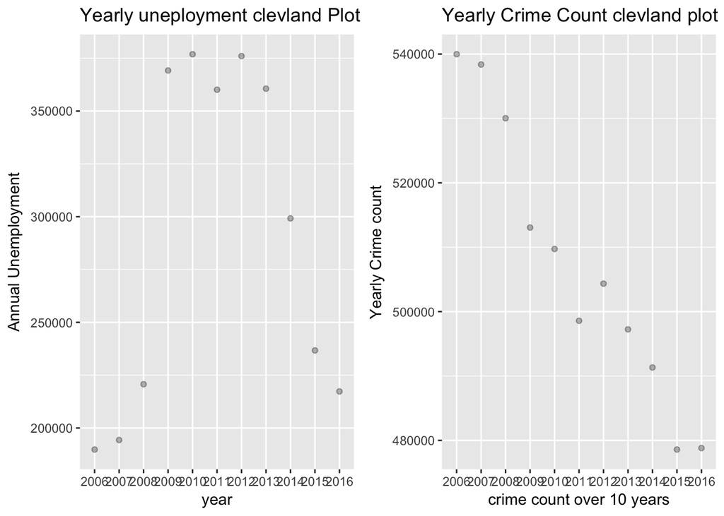

```r
x1 =ggplot(crime_df, aes(x=year,y=AnnAvg)) +
  geom_point( alpha=0.3)+
ylab("Annual Unemployment")+
  ggtitle("Yearly uneployment clevland Plot")

x2=  ggplot(crime_df, aes(x=year,y=CrimeCount)) +
  geom_point( alpha=0.3)+xlab("crime count over 10 years")+
ylab(" Yearly Crime count ")+
  ggtitle("Yearly Crime Count clevland plot")




grid.arrange(x1,x2,nrow=1)
```

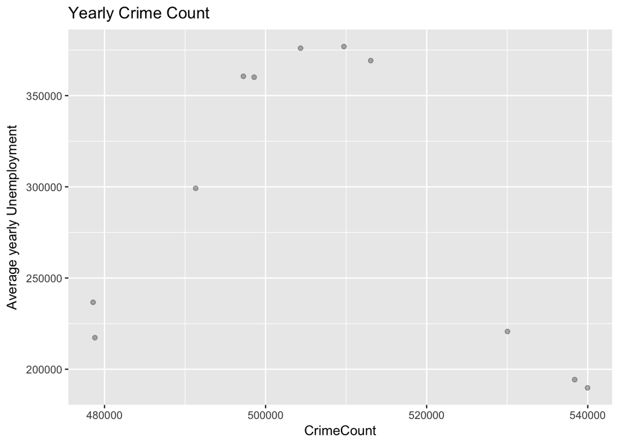

```r
 ggplot(crime_df,aes(x=CrimeCount,y=AnnAvg))+geom_point(alpha=0.3)+ylab(" Average yearly Unemployment ")+
  ggtitle("Yearly Crime Count")
```

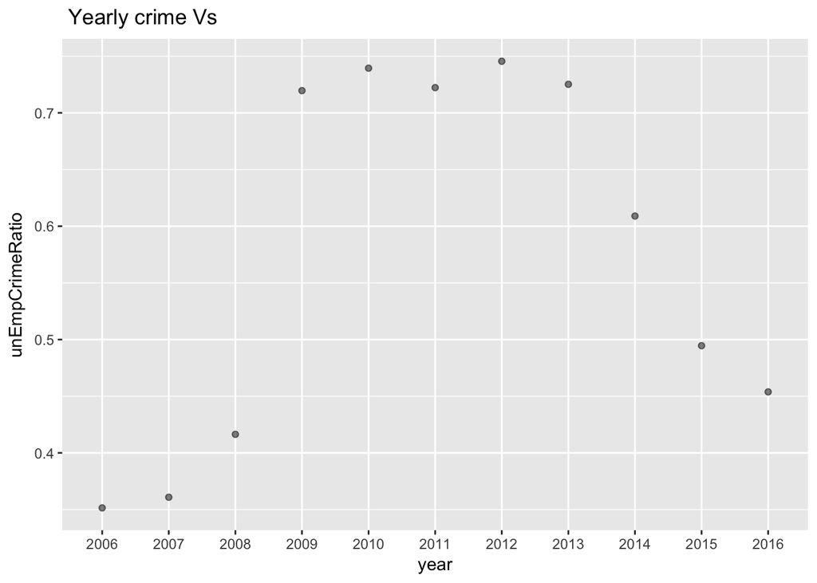

```r
ggplot(crime_df, aes(x=year, y=unEmpCrimeRatio)) +
  geom_point(alpha=0.5) +
  ggtitle(" Yearly crime Vs ")
```

```r
library(tidyr)
crime_df_master
```

[output not shown]

[output cut: 57 more lines]

```r
crime_df_master%>%mutate(year=as.character(year(DateReport)))%>%group_by(year,Level)%>%dplyr::summarise(CntByYear=n())%>% drop_na()->crime_df_master1

crime_df_master1 <- spread(crime_df_master1,Level,CntByYear)
crime_df_master1
```

```
## # A tibble: 11 x 4
## # Groups:   year [11]
##    year  FELONY MISDEMEANOR VIOLATION
##  * <chr>  <int>       <int>     <int>
##  1 2006  175544      294708     69725
##  2 2007  168532      303548     66300
##  3 2008  165025      302813     62196
##  4 2009  151167      301949     59940
##  5 2010  147613      303484     58631
##  6 2011  148313      294835     55428
##  7 2012  154064      292053     58224
##  8 2013  154660      283819     58763
##  9 2014  151209      277186     62924
## 10 2015  151296      264179     63103
## 11 2016  149842      262070     66892
```

```r
write.csv(crime_df_master1, "crime_master.csv")
```